# Data Wrangling

September 14, 2026

Jo Hardin

# Agenda 9/14/26

1. Tidy data

# What are data?

| species | island | bill_length_mm | bill_depth_mm | flipper_length_mm | body_mass_g | sex | year |
| --- | --- | --- | --- | --- | --- | --- | --- |
| Adelie | Torgersen | 39.1 | 18.7 | 181 | 3750 | male | 2007 |
| Adelie | Torgersen | 39.5 | 17.4 | 186 | 3800 | female | 2007 |
| Adelie | Torgersen | 40.3 | 18.0 | 195 | 3250 | female | 2007 |
| Adelie | Torgersen | NA | NA | NA | NA | NA | 2007 |
| Adelie | Torgersen | 36.7 | 19.3 | 193 | 3450 | female | 2007 |
| Adelie | Torgersen | 39.3 | 20.6 | 190 | 3650 | male | 2007 |

## Tidy data

- each row = a unit of observation (here, a penguin)
- each column = a measure on some variable of interest, either quantitative (numbers with units) or categorical (discrete possibilities or categories)
- each entry contains a single data value; no analysis, summaries, footnotes, comments, etc, and only one value per cell

## Definition of `datum`

The definition of **datum** can be much broader:

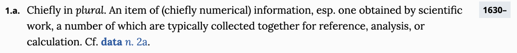

Definition of datum from the [Oxford English Dictionary](https://www.oed.com/search/dictionary/?scope=Entries&q=datum)

## Not tidy – Active Duty Military

The Active Duty data are not tidy! What are the cases? How are the data not tidy? What might the data look like in tidy form? Suppose that the case was “an individual in the armed forces.” What variables would you use to capture the information in the [following table](https://docs.google.com/spreadsheets/d/1Ow6Cm4z-Z1Yybk3i352msulYCEDOUaOghmo9ALajyHo/edit#gid=1811988794)?

[figure not shown]

## Tidying data

How would you wrangle each data example into a tidy format?

1. the emails in your inbox
2. social media posts
3. images
4. videos
5. audio files

# Agenda 9/16/26

1. Data verbs

## Tidy packages: the tidyverse

[figure not shown]

image credit: https://www.tidyverse.org/.

# Verbs

Most data wrangling happens with a set of data verbs. Verbs are **functions** that act on data frames.

The first argument of each data verb is the data frame.

The output of a data verb is a data frame.

## Some Basic Verbs

- `filter()`
- `arrange()`
- `select()`
- `mutate()`
- `summarize()`
- `group_by()`

## (out of) NYC, flights data (2013)

```r
library(nycflights13)
flights
```

| year | month | day | dep_time | sched_dep_time | dep_delay | arr_time | sched_arr_time | arr_delay | carrier | flight | tailnum | origin | dest | air_time | distance | hour | minute | time_hour |
| --- | --- | --- | --- | --- | --- | --- | --- | --- | --- | --- | --- | --- | --- | --- | --- | --- | --- | --- |
| 2013 | 1 | 1 | 517 | 515 | 2 | 830 | 819 | 11 | UA | 1545 | N14228 | EWR | IAH | 227 | 1400 | 5 | 15 | 2013-01-01 05:00:00 |
| 2013 | 1 | 1 | 533 | 529 | 4 | 850 | 830 | 20 | UA | 1714 | N24211 | LGA | IAH | 227 | 1416 | 5 | 29 | 2013-01-01 05:00:00 |
| 2013 | 1 | 1 | 542 | 540 | 2 | 923 | 850 | 33 | AA | 1141 | N619AA | JFK | MIA | 160 | 1089 | 5 | 40 | 2013-01-01 05:00:00 |
| 2013 | 1 | 1 | 544 | 545 | -1 | 1004 | 1022 | -18 | B6 | 725 | N804JB | JFK | BQN | 183 | 1576 | 5 | 45 | 2013-01-01 05:00:00 |
| 2013 | 1 | 1 | 554 | 600 | -6 | 812 | 837 | -25 | DL | 461 | N668DN | LGA | ATL | 116 | 762 | 6 | 0 | 2013-01-01 06:00:00 |
| 2013 | 1 | 1 | 554 | 558 | -4 | 740 | 728 | 12 | UA | 1696 | N39463 | EWR | ORD | 150 | 719 | 5 | 58 | 2013-01-01 05:00:00 |
| 2013 | 1 | 1 | 555 | 600 | -5 | 913 | 854 | 19 | B6 | 507 | N516JB | EWR | FLL | 158 | 1065 | 6 | 0 | 2013-01-01 06:00:00 |
| 2013 | 1 | 1 | 557 | 600 | -3 | 709 | 723 | -14 | EV | 5708 | N829AS | LGA | IAD | 53 | 229 | 6 | 0 | 2013-01-01 06:00:00 |
| 2013 | 1 | 1 | 557 | 600 | -3 | 838 | 846 | -8 | B6 | 79 | N593JB | JFK | MCO | 140 | 944 | 6 | 0 | 2013-01-01 06:00:00 |
| 2013 | 1 | 1 | 558 | 600 | -2 | 753 | 745 | 8 | AA | 301 | N3ALAA | LGA | ORD | 138 | 733 | 6 | 0 | 2013-01-01 06:00:00 |

[output cut: 9990 more lines]

## `filter()`

Allows you to select a subset of the **rows** of a data frame. The first argument is the name of the data frame, the following arguments are the filters that you’d like to apply

For all flights on January 1st:

```r
filter(flights, month == 1, day == 1)
```

| year | month | day | dep_time | sched_dep_time | dep_delay | arr_time | sched_arr_time | arr_delay | carrier | flight | tailnum | origin | dest | air_time | distance | hour | minute | time_hour |
| --- | --- | --- | --- | --- | --- | --- | --- | --- | --- | --- | --- | --- | --- | --- | --- | --- | --- | --- |
| 2013 | 1 | 1 | 517 | 515 | 2 | 830 | 819 | 11 | UA | 1545 | N14228 | EWR | IAH | 227 | 1400 | 5 | 15 | 2013-01-01 05:00:00 |
| 2013 | 1 | 1 | 533 | 529 | 4 | 850 | 830 | 20 | UA | 1714 | N24211 | LGA | IAH | 227 | 1416 | 5 | 29 | 2013-01-01 05:00:00 |
| 2013 | 1 | 1 | 542 | 540 | 2 | 923 | 850 | 33 | AA | 1141 | N619AA | JFK | MIA | 160 | 1089 | 5 | 40 | 2013-01-01 05:00:00 |
| 2013 | 1 | 1 | 544 | 545 | -1 | 1004 | 1022 | -18 | B6 | 725 | N804JB | JFK | BQN | 183 | 1576 | 5 | 45 | 2013-01-01 05:00:00 |
| 2013 | 1 | 1 | 554 | 600 | -6 | 812 | 837 | -25 | DL | 461 | N668DN | LGA | ATL | 116 | 762 | 6 | 0 | 2013-01-01 06:00:00 |
| 2013 | 1 | 1 | 554 | 558 | -4 | 740 | 728 | 12 | UA | 1696 | N39463 | EWR | ORD | 150 | 719 | 5 | 58 | 2013-01-01 05:00:00 |
| 2013 | 1 | 1 | 555 | 600 | -5 | 913 | 854 | 19 | B6 | 507 | N516JB | EWR | FLL | 158 | 1065 | 6 | 0 | 2013-01-01 06:00:00 |
| 2013 | 1 | 1 | 557 | 600 | -3 | 709 | 723 | -14 | EV | 5708 | N829AS | LGA | IAD | 53 | 229 | 6 | 0 | 2013-01-01 06:00:00 |
| 2013 | 1 | 1 | 557 | 600 | -3 | 838 | 846 | -8 | B6 | 79 | N593JB | JFK | MCO | 140 | 944 | 6 | 0 | 2013-01-01 06:00:00 |
| 2013 | 1 | 1 | 558 | 600 | -2 | 753 | 745 | 8 | AA | 301 | N3ALAA | LGA | ORD | 138 | 733 | 6 | 0 | 2013-01-01 06:00:00 |

[output cut: 832 more lines]

## Constructing filters

Filters are constructed of **logical operators**: `<`, `>`, `<=`, `>=`, `==`, `!=` (and some others).

Adding them one by one to `filter()` is akin to saying “this AND that”. To say “this OR that OR both”, use |.

```r
filter(flights, month == 1 | month == 2)
```

| year | month | day | dep_time | sched_dep_time | dep_delay | arr_time | sched_arr_time | arr_delay | carrier | flight | tailnum | origin | dest | air_time | distance | hour | minute | time_hour |
| --- | --- | --- | --- | --- | --- | --- | --- | --- | --- | --- | --- | --- | --- | --- | --- | --- | --- | --- |
| 2013 | 1 | 1 | 517 | 515 | 2 | 830 | 819 | 11 | UA | 1545 | N14228 | EWR | IAH | 227 | 1400 | 5 | 15 | 2013-01-01 05:00:00 |
| 2013 | 1 | 1 | 533 | 529 | 4 | 850 | 830 | 20 | UA | 1714 | N24211 | LGA | IAH | 227 | 1416 | 5 | 29 | 2013-01-01 05:00:00 |
| 2013 | 1 | 1 | 542 | 540 | 2 | 923 | 850 | 33 | AA | 1141 | N619AA | JFK | MIA | 160 | 1089 | 5 | 40 | 2013-01-01 05:00:00 |
| 2013 | 1 | 1 | 544 | 545 | -1 | 1004 | 1022 | -18 | B6 | 725 | N804JB | JFK | BQN | 183 | 1576 | 5 | 45 | 2013-01-01 05:00:00 |
| 2013 | 1 | 1 | 554 | 600 | -6 | 812 | 837 | -25 | DL | 461 | N668DN | LGA | ATL | 116 | 762 | 6 | 0 | 2013-01-01 06:00:00 |
| 2013 | 1 | 1 | 554 | 558 | -4 | 740 | 728 | 12 | UA | 1696 | N39463 | EWR | ORD | 150 | 719 | 5 | 58 | 2013-01-01 05:00:00 |
| 2013 | 1 | 1 | 555 | 600 | -5 | 913 | 854 | 19 | B6 | 507 | N516JB | EWR | FLL | 158 | 1065 | 6 | 0 | 2013-01-01 06:00:00 |
| 2013 | 1 | 1 | 557 | 600 | -3 | 709 | 723 | -14 | EV | 5708 | N829AS | LGA | IAD | 53 | 229 | 6 | 0 | 2013-01-01 06:00:00 |
| 2013 | 1 | 1 | 557 | 600 | -3 | 838 | 846 | -8 | B6 | 79 | N593JB | JFK | MCO | 140 | 944 | 6 | 0 | 2013-01-01 06:00:00 |
| 2013 | 1 | 1 | 558 | 600 | -2 | 753 | 745 | 8 | AA | 301 | N3ALAA | LGA | ORD | 138 | 733 | 6 | 0 | 2013-01-01 06:00:00 |

[output cut: 9990 more lines]

## Practice

Construct filters to isolate:

1. Flights that left on St. Patrick’s Day.
2. Flights that were destined for Chicago’s primary airport.
3. Flights that were destined for Chicago’s primary airport and were operated by United Airlines.
4. Flights with flight times more than 2000 miles or that were in the air more than 5 hours.

## Solution

1. Flights that left on St. Patrick’s Day.
2. Flights that were destined for Chicago’s primary airport.
3. Flights that were destined for Chicago’s primary airport and were operated by United Airlines.
4. Flights with flight times more than 2000 miles or that were in the air more than 5 hours.

```r
filter(flights, month == 3, day == 17)
filter(flights, dest == "ORD")
filter(flights, dest == "ORD", carrier == "UA")
filter(flights, distance > 2000 | air_time > 5 * 60)
```

## `arrange()`

`arrange()` reorders the rows: It takes a data frame, and a set of column names (or more complicated expressions) to order by. If you provide more than one column name, each additional column will be used to break ties in the values of preceding columns:

```r
arrange(flights, year, month, day)
```

| year | month | day | dep_time | sched_dep_time | dep_delay | arr_time | sched_arr_time | arr_delay | carrier | flight | tailnum | origin | dest | air_time | distance | hour | minute | time_hour |
| --- | --- | --- | --- | --- | --- | --- | --- | --- | --- | --- | --- | --- | --- | --- | --- | --- | --- | --- |
| 2013 | 1 | 1 | 517 | 515 | 2 | 830 | 819 | 11 | UA | 1545 | N14228 | EWR | IAH | 227 | 1400 | 5 | 15 | 2013-01-01 05:00:00 |
| 2013 | 1 | 1 | 533 | 529 | 4 | 850 | 830 | 20 | UA | 1714 | N24211 | LGA | IAH | 227 | 1416 | 5 | 29 | 2013-01-01 05:00:00 |
| 2013 | 1 | 1 | 542 | 540 | 2 | 923 | 850 | 33 | AA | 1141 | N619AA | JFK | MIA | 160 | 1089 | 5 | 40 | 2013-01-01 05:00:00 |
| 2013 | 1 | 1 | 544 | 545 | -1 | 1004 | 1022 | -18 | B6 | 725 | N804JB | JFK | BQN | 183 | 1576 | 5 | 45 | 2013-01-01 05:00:00 |
| 2013 | 1 | 1 | 554 | 600 | -6 | 812 | 837 | -25 | DL | 461 | N668DN | LGA | ATL | 116 | 762 | 6 | 0 | 2013-01-01 06:00:00 |
| 2013 | 1 | 1 | 554 | 558 | -4 | 740 | 728 | 12 | UA | 1696 | N39463 | EWR | ORD | 150 | 719 | 5 | 58 | 2013-01-01 05:00:00 |
| 2013 | 1 | 1 | 555 | 600 | -5 | 913 | 854 | 19 | B6 | 507 | N516JB | EWR | FLL | 158 | 1065 | 6 | 0 | 2013-01-01 06:00:00 |
| 2013 | 1 | 1 | 557 | 600 | -3 | 709 | 723 | -14 | EV | 5708 | N829AS | LGA | IAD | 53 | 229 | 6 | 0 | 2013-01-01 06:00:00 |
| 2013 | 1 | 1 | 557 | 600 | -3 | 838 | 846 | -8 | B6 | 79 | N593JB | JFK | MCO | 140 | 944 | 6 | 0 | 2013-01-01 06:00:00 |
| 2013 | 1 | 1 | 558 | 600 | -2 | 753 | 745 | 8 | AA | 301 | N3ALAA | LGA | ORD | 138 | 733 | 6 | 0 | 2013-01-01 06:00:00 |

[output cut: 9990 more lines]

## `arrange()`

Use `desc()` to sort in descending order.

```r
arrange(flights, desc(dep_delay))
```

| year | month | day | dep_time | sched_dep_time | dep_delay | arr_time | sched_arr_time | arr_delay | carrier | flight | tailnum | origin | dest | air_time | distance | hour | minute | time_hour |
| --- | --- | --- | --- | --- | --- | --- | --- | --- | --- | --- | --- | --- | --- | --- | --- | --- | --- | --- |
| 2013 | 1 | 9 | 641 | 900 | 1301 | 1242 | 1530 | 1272 | HA | 51 | N384HA | JFK | HNL | 640 | 4983 | 9 | 0 | 2013-01-09 09:00:00 |
| 2013 | 6 | 15 | 1432 | 1935 | 1137 | 1607 | 2120 | 1127 | MQ | 3535 | N504MQ | JFK | CMH | 74 | 483 | 19 | 35 | 2013-06-15 19:00:00 |
| 2013 | 1 | 10 | 1121 | 1635 | 1126 | 1239 | 1810 | 1109 | MQ | 3695 | N517MQ | EWR | ORD | 111 | 719 | 16 | 35 | 2013-01-10 16:00:00 |
| 2013 | 9 | 20 | 1139 | 1845 | 1014 | 1457 | 2210 | 1007 | AA | 177 | N338AA | JFK | SFO | 354 | 2586 | 18 | 45 | 2013-09-20 18:00:00 |
| 2013 | 7 | 22 | 845 | 1600 | 1005 | 1044 | 1815 | 989 | MQ | 3075 | N665MQ | JFK | CVG | 96 | 589 | 16 | 0 | 2013-07-22 16:00:00 |
| 2013 | 4 | 10 | 1100 | 1900 | 960 | 1342 | 2211 | 931 | DL | 2391 | N959DL | JFK | TPA | 139 | 1005 | 19 | 0 | 2013-04-10 19:00:00 |
| 2013 | 3 | 17 | 2321 | 810 | 911 | 135 | 1020 | 915 | DL | 2119 | N927DA | LGA | MSP | 167 | 1020 | 8 | 10 | 2013-03-17 08:00:00 |
| 2013 | 6 | 27 | 959 | 1900 | 899 | 1236 | 2226 | 850 | DL | 2007 | N3762Y | JFK | PDX | 313 | 2454 | 19 | 0 | 2013-06-27 19:00:00 |
| 2013 | 7 | 22 | 2257 | 759 | 898 | 121 | 1026 | 895 | DL | 2047 | N6716C | LGA | ATL | 109 | 762 | 7 | 59 | 2013-07-22 07:00:00 |
| 2013 | 12 | 5 | 756 | 1700 | 896 | 1058 | 2020 | 878 | AA | 172 | N5DMAA | EWR | MIA | 149 | 1085 | 17 | 0 | 2013-12-05 17:00:00 |

[output cut: 9990 more lines]

## `select()`

Often you work with large datasets with many columns where only a few are actually of interest to you. `select()` allows you to rapidly zoom in on a useful subset using operations that usually only work on numeric variable positions:

```r
select(flights, year, month, day)
```

| year | month | day |
| --- | --- | --- |
| 2013 | 1 | 1 |
| 2013 | 1 | 1 |
| 2013 | 1 | 1 |
| 2013 | 1 | 1 |
| 2013 | 1 | 1 |
| 2013 | 1 | 1 |
| 2013 | 1 | 1 |
| 2013 | 1 | 1 |
| 2013 | 1 | 1 |
| 2013 | 1 | 1 |

[output cut: 9990 more lines]

## `select()`

You can exclude columns using `-` and specify a range using `:`.

```r
select(flights, -(year:day))
```

| dep_time | sched_dep_time | dep_delay | arr_time | sched_arr_time | arr_delay | carrier | flight | tailnum | origin | dest | air_time | distance | hour | minute | time_hour |
| --- | --- | --- | --- | --- | --- | --- | --- | --- | --- | --- | --- | --- | --- | --- | --- |
| 517 | 515 | 2 | 830 | 819 | 11 | UA | 1545 | N14228 | EWR | IAH | 227 | 1400 | 5 | 15 | 2013-01-01 05:00:00 |
| 533 | 529 | 4 | 850 | 830 | 20 | UA | 1714 | N24211 | LGA | IAH | 227 | 1416 | 5 | 29 | 2013-01-01 05:00:00 |
| 542 | 540 | 2 | 923 | 850 | 33 | AA | 1141 | N619AA | JFK | MIA | 160 | 1089 | 5 | 40 | 2013-01-01 05:00:00 |
| 544 | 545 | -1 | 1004 | 1022 | -18 | B6 | 725 | N804JB | JFK | BQN | 183 | 1576 | 5 | 45 | 2013-01-01 05:00:00 |
| 554 | 600 | -6 | 812 | 837 | -25 | DL | 461 | N668DN | LGA | ATL | 116 | 762 | 6 | 0 | 2013-01-01 06:00:00 |
| 554 | 558 | -4 | 740 | 728 | 12 | UA | 1696 | N39463 | EWR | ORD | 150 | 719 | 5 | 58 | 2013-01-01 05:00:00 |
| 555 | 600 | -5 | 913 | 854 | 19 | B6 | 507 | N516JB | EWR | FLL | 158 | 1065 | 6 | 0 | 2013-01-01 06:00:00 |
| 557 | 600 | -3 | 709 | 723 | -14 | EV | 5708 | N829AS | LGA | IAD | 53 | 229 | 6 | 0 | 2013-01-01 06:00:00 |
| 557 | 600 | -3 | 838 | 846 | -8 | B6 | 79 | N593JB | JFK | MCO | 140 | 944 | 6 | 0 | 2013-01-01 06:00:00 |
| 558 | 600 | -2 | 753 | 745 | 8 | AA | 301 | N3ALAA | LGA | ORD | 138 | 733 | 6 | 0 | 2013-01-01 06:00:00 |

[output cut: 9990 more lines]

## `mutate()`

As well as selecting from the set of existing columns, it’s often useful to add new columns that are functions of existing columns. This is the job of `mutate()`:

```r
select(
  mutate(flights, gain = dep_delay - arr_delay),
  flight,
  dep_delay,
  arr_delay,
  gain
)
```

| flight | dep_delay | arr_delay | gain |
| --- | --- | --- | --- |
| 1545 | 2 | 11 | -9 |
| 1714 | 4 | 20 | -16 |
| 1141 | 2 | 33 | -31 |
| 725 | -1 | -18 | 17 |
| 461 | -6 | -25 | 19 |
| 1696 | -4 | 12 | -16 |
| 507 | -5 | 19 | -24 |
| 5708 | -3 | -14 | 11 |
| 79 | -3 | -8 | 5 |
| 301 | -2 | 8 | -10 |

[output cut: 9990 more lines]

## `summarize()`

`summarize()` collapses a data frame to a single row based on some function. It’s not very useful yet, but it will be.

```r
summarize(flights, delay = mean(dep_delay, na.rm = TRUE))
```

| delay |
| --- |
| 12.63907 |

## Practice

**Mutate** the data to create a new column that contains the average speed traveled by the plane for each flight.

**Select** the new variable and save it, along with tailnum, as a new data frame object.

## Practice

**Mutate** the data to create a new column that contains the average speed traveled by the plane for each flight.

**Select** the new variable and save it, along with tailnum, as a new data frame object.

```r
flights2 <- mutate(flights, speed = distance / (air_time / 60))
speed_data <- select(flights2, tailnum, speed)
```

## `group_by()`

`summarize()` is even more powerful when combined with the idea of “group by”, repeating the operation separately on groups of observations within the dataset.

The `group_by()` function describes how to break a dataset down into groups of rows.

`group_by()` does not change anything about the data frame. Rather, it *holds* the rows of the data frame separately so that any future verbs applied to the data frame are done separately per group being held.

## `group_by()`

Find the fastest airplanes in the bunch, measured as the average speed per airplane.

```r
by_tailnum <- group_by(speed_data, tailnum)
avg_speed <- summarize(
  by_tailnum,
  count = n(),
  avg_speed = mean(speed, na.rm = TRUE)
)
arrange(avg_speed, desc(avg_speed))
```

| tailnum | count | avg_speed |
| --- | --- | --- |
| N228UA | 1 | 500.8163 |
| N315AS | 1 | 498.6851 |
| N654UA | 1 | 498.5821 |
| N819AW | 1 | 490.3448 |
| N382HA | 26 | 485.6026 |
| N388HA | 36 | 484.3891 |
| N391HA | 21 | 484.0645 |
| N777UA | 1 | 483.3645 |
| N385HA | 28 | 482.8947 |
| N392HA | 13 | 482.2468 |

[output cut: 4034 more lines]

## Chaining

Instead of applying each verb step-by-step, we can chain them into a single data pipeline, connected with the `|>` operator. You start the pipeline with a data frame and then pass it to each function in turn.

The pipe syntax (`|>`) takes a data frame and sends it to the argument of a function. The mapping goes to the first available argument in the function. For example:

`x |> f()` is the same as `f(x)`

`x |> f(y)` is the same as `f(x, y)`

## Pipe in action

```r
sqrt(log(10))
```

```
[1] 1.517427
```

is the same as

```r
10 |>
  log() |>
  sqrt()
```

```
[1] 1.517427
```

## Mornings

```r
me_step1 <- dress(me, what = sports)
me_step2 <- exercise(me_step1, how = running)
me_step3 <- eat(me_step2, choice = cereal)
me_step4 <- dress(me_step3, what = school)
me_step5 <- commute(me_step4, transportation = bike)
```

## Mornings

```r
commute(dress(eat(exercise(dress(me, what = sports), how = running), choice = cereal), what = school), transportation = bike)
```

## Morning

(better??)

```r
commute(
  dress(
    eat(
      exercise(
        dress(me, what = sports),
        how = running
      ),
      choice = cereal
    ),
    what = school
  ),
  transportation = bike
)
```

## Mornings

```r
me |>
  dress(what = sports) |>
  exercise(how = running) |>
  eat(choice = cereal) |>
  dress(what = school) |>
  commute(transportation = bike)
```

## Flights

- No pipe
- Pipe

```r
flights2 <- mutate(flights, speed = distance / (air_time / 60))
tail_speed <- select(flights2, tailnum, speed)
tail_speed_grp <- group_by(tail_speed, tailnum)
tail_ave <- summarize(
  tail_speed_grp,
  number = n(),
  avg_speed = mean(speed, na.rm = TRUE)
)
arrange(tail_ave, desc(avg_speed))
```

| tailnum | number | avg_speed |
| --- | --- | --- |
| N228UA | 1 | 500.8163 |
| N315AS | 1 | 498.6851 |
| N654UA | 1 | 498.5821 |
| N819AW | 1 | 490.3448 |
| N382HA | 26 | 485.6026 |
| N388HA | 36 | 484.3891 |
| N391HA | 21 | 484.0645 |
| N777UA | 1 | 483.3645 |
| N385HA | 28 | 482.8947 |
| N392HA | 13 | 482.2468 |

[output cut: 4034 more lines]

```r
flights |>
  mutate(speed = distance / (air_time / 60)) |>
  select(tailnum, speed) |>
  group_by(tailnum) |>
  summarize(number = n(), avg_speed = mean(speed, na.rm = TRUE)) |>
  arrange(desc(avg_speed))
```

| tailnum | number | avg_speed |
| --- | --- | --- |
| N228UA | 1 | 500.8163 |
| N315AS | 1 | 498.6851 |
| N654UA | 1 | 498.5821 |
| N819AW | 1 | 490.3448 |
| N382HA | 26 | 485.6026 |
| N388HA | 36 | 484.3891 |
| N391HA | 21 | 484.0645 |
| N777UA | 1 | 483.3645 |
| N385HA | 28 | 482.8947 |
| N392HA | 13 | 482.2468 |

[output cut: 4034 more lines]

## Order matters

- filter then mutate
- mutate then filter

```r
flights |>
  filter(dep_delay > 500) |>
  group_by(carrier) |>
  mutate(mean_delay = mean(dep_delay, na.rm = TRUE)) |>
  select(year, month, day, dep_delay, mean_delay, origin, dest, carrier)
```

| year | month | day | dep_delay | mean_delay | origin | dest | carrier |
| --- | --- | --- | --- | --- | --- | --- | --- |
| 2013 | 1 | 1 | 853 | 999.8000 | JFK | BWI | MQ |
| 2013 | 1 | 9 | 1301 | 1301.0000 | JFK | HNL | HA |
| 2013 | 1 | 10 | 1126 | 999.8000 | EWR | ORD | MQ |
| 2013 | 1 | 13 | 599 | 715.6296 | JFK | ATL | DL |
| 2013 | 1 | 16 | 502 | 502.0000 | EWR | MCO | B6 |
| 2013 | 10 | 14 | 702 | 715.6296 | EWR | ATL | DL |
| 2013 | 11 | 3 | 798 | 715.6296 | EWR | ATL | DL |
| 2013 | 11 | 24 | 636 | 714.0714 | JFK | MIA | AA |
| 2013 | 12 | 1 | 687 | 715.6296 | JFK | SAT | DL |
| 2013 | 12 | 5 | 896 | 714.0714 | EWR | MIA | AA |

[output cut: 50 more lines]

```r
flights |>
  group_by(carrier) |>
  mutate(mean_delay = mean(dep_delay, na.rm = TRUE)) |>
  filter(dep_delay > 500) |>
  select(year, month, day, dep_delay, mean_delay, origin, dest, carrier)
```

| year | month | day | dep_delay | mean_delay | origin | dest | carrier |
| --- | --- | --- | --- | --- | --- | --- | --- |
| 2013 | 1 | 1 | 853 | 10.552041 | JFK | BWI | MQ |
| 2013 | 1 | 9 | 1301 | 4.900585 | JFK | HNL | HA |
| 2013 | 1 | 10 | 1126 | 10.552041 | EWR | ORD | MQ |
| 2013 | 1 | 13 | 599 | 9.264505 | JFK | ATL | DL |
| 2013 | 1 | 16 | 502 | 13.022522 | EWR | MCO | B6 |
| 2013 | 10 | 14 | 702 | 9.264505 | EWR | ATL | DL |
| 2013 | 11 | 3 | 798 | 9.264505 | EWR | ATL | DL |
| 2013 | 11 | 24 | 636 | 8.586016 | JFK | MIA | AA |
| 2013 | 12 | 1 | 687 | 9.264505 | JFK | SAT | DL |
| 2013 | 12 | 5 | 896 | 8.586016 | EWR | MIA | AA |

[output cut: 50 more lines]

## Practice

Form a chain that creates a data frame containing only carrier and the mean departure delay time. Which carriers have the highest and lowest mean delays?

## Practice

Form a chain that creates a data frame containing only carrier and the mean departure delay time. Which carriers have the highest and lowest mean delays?

```r
flights |>
  group_by(carrier) |>
  summarize(avg_delay = mean(dep_delay, na.rm = TRUE)) |>
  arrange(desc(avg_delay))
```

| carrier | avg_delay |
| --- | --- |
| F9 | 20.215543 |
| EV | 19.955390 |
| YV | 18.996330 |
| FL | 18.726075 |
| WN | 17.711744 |
| 9E | 16.725769 |
| B6 | 13.022522 |
| VX | 12.869421 |
| OO | 12.586207 |
| UA | 12.106073 |

[output cut: 6 more lines]

## Practice again

Say you’re curious about the relationship between the number of flights that each plane made in 2013, the mean distance that each of those planes flew, and the mean arrival delay. You also want to exclude the edge cases from your analysis, so focus on the planes that have logged more than 20 flights and flown an average distance of less than 2000 miles. Please form the chain that creates this dataset.

## Solution

```r
delay_data <- flights |>
  group_by(tailnum) |>
  summarize(
    number = n(),
    dist = mean(distance, na.rm = TRUE),
    delay = mean(arr_delay, na.rm = TRUE)
  ) |>
  filter(number > 20, dist < 2000)
```

## Visualizing the data

- Viz
- Code

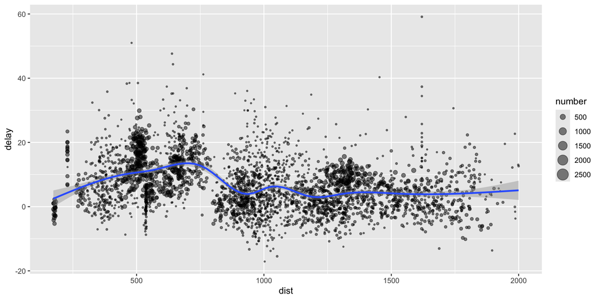

```r
delay_data |>
  ggplot(aes(dist, delay)) +
  geom_point(aes(size = number), alpha = 1 / 2) +
  geom_smooth() +
  scale_size_area()
```

When `scale_size_area` is used, the default behavior is to scale the area of points to be proportional to the value.